# EasyVisa_Full_Code_Notebook (1)

### Does visa status vary with changes in the prevailing wage set to protect both local talent and foreign workers?

```python
df_copy.groupby('unit_of_wage')['prevailing_wage'].mean()
```

| unit_of_wage | prevailing_wage |
| --- | --- |
| Hour | 414.570513 |
| Month | 87592.864045 |
| Week | 85606.820515 |
| Year | 81228.077133 |

**dtype:** float64

**Observation**

1. The data shows that the unit_of_wage 'Hour' is a per-day amount, whearas the other three unit_of_wage categories are an annual salary amount.

#### Does the unit of prevailing wage (Hourly, Weekly, etc.) have any impact on the likelihood of visa application certification?

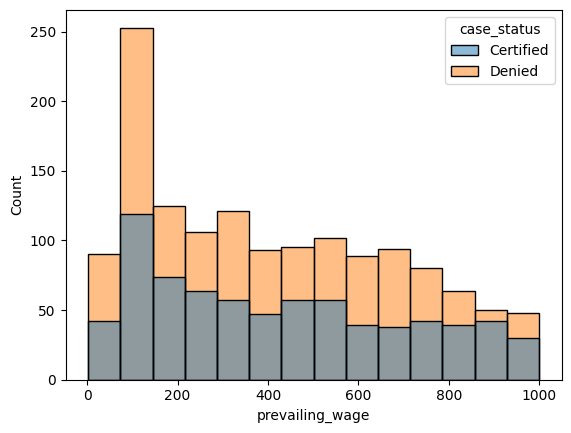

```python
#create a dataframe only of workers applying for jobs with a *unit_wage* of 'Hour'
df_hourly = df_copy[df_copy.unit_of_wage=='Hour']
#show a distribution of the *prevailing_wage* within this dataframe, along with the ratio of *case_status* within each bin
sns.histplot(data=df_hourly, x='prevailing_wage', hue='case_status')
plt.show()
```

```python
#create bins that categorize applicants by the per-day wage of the job he or she is applying for
bins = list(np.arange(0,1100,200))
#assign each applicant to a category
df_hourly['income_per_day'] = pd.cut(df_hourly['prevailing_wage'], bins)
df_hourly.groupby('income_per_day')['case_status'].value_counts()
```

| income_per_day | case_status | count |
| --- | --- | --- |
| (0, 200] | Denied | 448 |
|  | Certified | 219 |
| (200, 400] | Denied | 301 |
|  | Certified | 166 |
| (400, 600] | Denied | 274 |
|  | Certified | 144 |
| (600, 800] | Denied | 239 |
|  | Certified | 116 |
| (800, 1000] | Denied | 148 |
|  | Certified | 102 |

**dtype:** int64

```
case_status     Certified  Denied   All
income_per_day
All                   747    1410  2157
(0, 200]              219     448   667
(200, 400]            166     301   467
(400, 600]            144     274   418
(600, 800]            116     239   355
(800, 1000]           102     148   250
------------------------------------------------------------------------------------------------------------------------
```

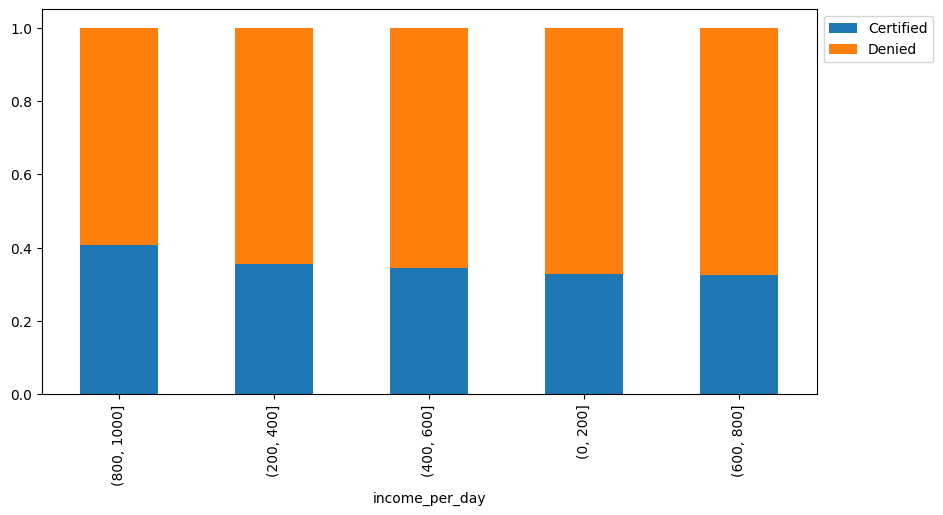

```python
stacked_barplot(df_hourly, 'income_per_day', 'case_status')
```

**observation**

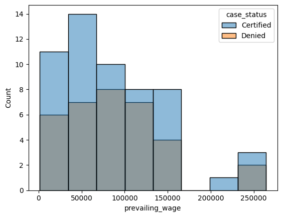

```python
#create a dataframe only of workers applying for jobs with a *unit_wage* of 'Hour'
df_monthly = df_copy[df_copy.unit_of_wage=='Month']
#show a distribution of the *prevailing_wage* within this dataframe, along with the ratio of *case_status* within each bin
sns.histplot(data=df_monthly, x='prevailing_wage', hue='case_status')
plt.show()
```

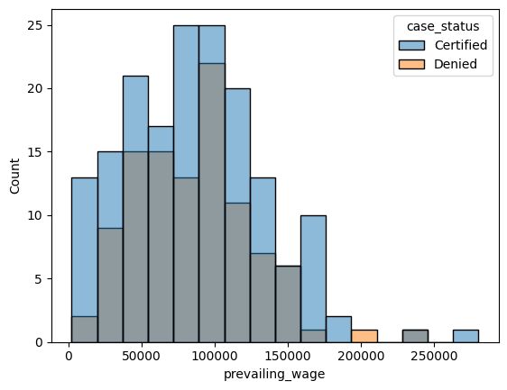

```python
#create a dataframe only of workers applying for jobs with a *unit_wage* of 'Hour'
df_weekly = df_copy[df_copy.unit_of_wage=='Week']
#show a distribution of the *prevailing_wage* within this dataframe, along with the ratio of *case_status* within each bin
sns.histplot(data=df_weekly, x='prevailing_wage', hue='case_status')
plt.show()
```

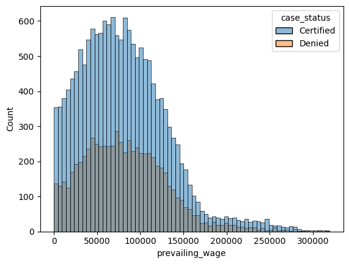

```python
#create a dataframe only of workers applying for jobs with a *unit_wage* of 'Hour'
df_yearly = df_copy[df_copy.unit_of_wage=='Year']
#show a distribution of the *prevailing_wage* within this dataframe, along with the ratio of *case_status* within each bin
sns.histplot(data=df_yearly, x='prevailing_wage', hue='case_status')
plt.show()
```

```python
bins = [0,25000,50000,75000,100000,125000,np.inf]
names = ['$0-25k','$25k-50k','$50k-75k','$75k-100k','$100k-125k','$125k+']
#assign an applicant to a category
df_yearly['income_per_year'] = pd.cut(df_yearly['prevailing_wage'], bins, labels=names)
df_yearly.groupby('income_per_year')['case_status'].value_counts()
```

| income_per_year | case_status | count |
| --- | --- | --- |
| $0-25k | Certified | 2066 |
|  | Denied | 752 |
| $25k-50k | Certified | 2801 |
|  | Denied | 1216 |
| $50k-75k | Certified | 3101 |
|  | Denied | 1342 |
| $75k-100k | Certified | 2963 |
|  | Denied | 1284 |
| $100k-125k | Certified | 2374 |
|  | Denied | 1117 |
| $125k+ | Certified | 2742 |
|  | Denied | 1204 |

**dtype:** int64

```
case_status      Certified  Denied    All
income_per_year
All                  16047    6915  22962
$50k-75k              3101    1342   4443
$75k-100k             2963    1284   4247
$25k-50k              2801    1216   4017
$125k+                2742    1204   3946
$100k-125k            2374    1117   3491
$0-25k                2066     752   2818
------------------------------------------------------------------------------------------------------------------------
```

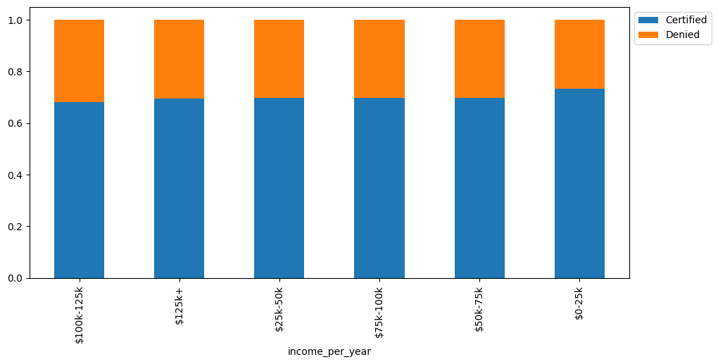

```python
stacked_barplot(df_yearly, 'income_per_year', 'case_status')
```

**Observation**

1. The distribution of wages is (as expected) right skewed, indicating a long-tail of jobs with annual salaries above 150,000 dollars.
2. As the distribution above shows, the ratio of approved to denied applications remains approximately equivalent across the range of wages.
3. In support of the observation above, there does not appear to be a significant change in ratio of approved to denied applications as income_per_year increases. To the contrary, the ratio may actually decrease as this prevailing_wage increases.
4. For applications for jobs with an income_per_year wage, the highest concentration of applications is for jobs with 50,000 to 75,000 dollars per year in salary.

[figure not shown]

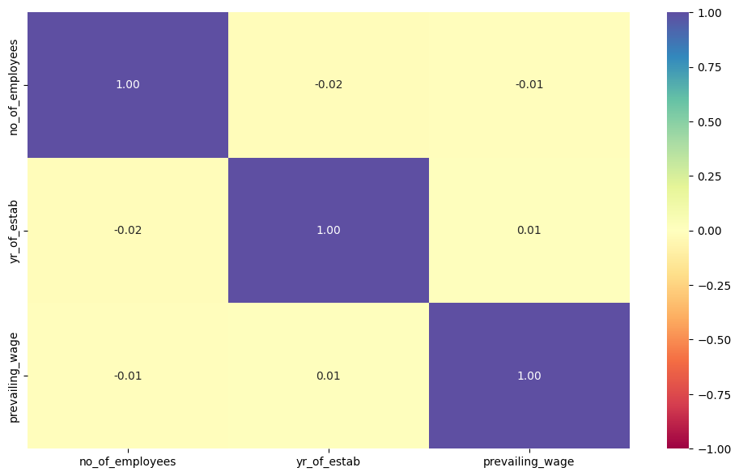

```python
# Creating a new variable with numerical columns
cols_list = df_copy.select_dtypes(include=np.number).columns.tolist()

# Visualizing a correlation map
plt.figure(figsize=(12, 7))
sns.heatmap(df_copy[cols_list].corr(), annot=True, vmin=-1, vmax=1, fmt=".2f", cmap="Spectral");
```

**Observation**

1. There doesn't seem to be any significant correlation between numerical variables.

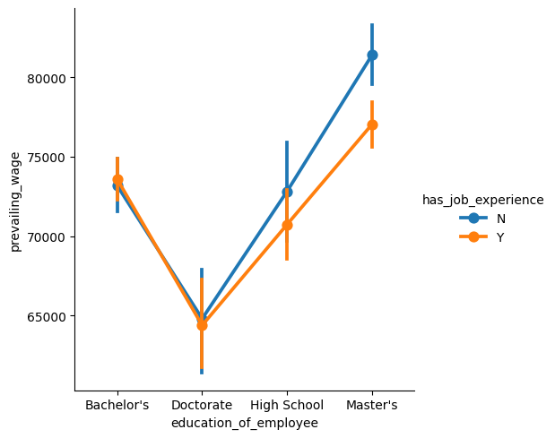

```python
sns.catplot(data=df_copy, x='education_of_employee', y='prevailing_wage', hue='has_job_experience', kind='point');
```

**Observation**

1. Higher wages are for employees who have master's degree.
2. At the same time its seen that they have no experience
3. Doctrate degree prevailing wages is less than high school degree holders